# Google Data Analytics Capstone

Cyclistic bike-share analysis

Anita

2022-06-24

### Introduction

For the capstone project of the Google Data Analytics certificate, I have chosen the Cyclistic bike share data to work on. For the case study, I will perform real-world tasks of a junior data analyst for the marketing team at Cyclistic, a fictional bike-share company in Chicago. To answer key business questions, I will follow the six steps of the data analysis process : Ask, Prepare, Process, Analyze, Share, and Act.

### The scenario

The director of marketing of Cyclistic, Lily Moreno, believes that the company’s future growth depends on maximizing the number of annual memberships. Hence, the marketing analyst team wants to understand how casual riders and annual members use Cyclistic bikes differently. From these insights, the analytics team could be able to design a new marketing strategy to convert casual riders into annual members.

Three questions will guide the future marketing campaign:

1.How do annual members and casual riders use Cyclistic bikes differently?

2.Why would casual riders buy Cyclistic annual memberships?

3.How can Cyclistic use digital media to influence casual riders to become members?

Moreno has assigned me the first question to answer: How do annual members and casual riders use Cyclistic bikes differently?

### The Ask phase

- A statement of the business task:

Cyclistic has concluded that annual members are much more profitable than casual riders. So, we want to design a marketing strategies and a campaign that helps us converting casual riders into annual members.

- My key stakeholders are:

1-Lily Moreno: The director of marketing and my manager. Moreno has initiated this strategy. The first stakeholder to deliver to.

2-The executive team: For Moreno´s idea to work, the executive team must approve our recommendations, so they must be backed up with compelling data insights and professional data visualizations.

### The Prepare phase

Data Source: Past 12 month of original bike share data set from 01/01/2021 to 31/12/2021 was extracted as 12 zipped .csv [files](https://divvy-tripdata.s3.amazonaws.com/index.html). The data is made available and licensed by Motivate International Inc under this [license](https://ride.divvybikes.com/data-license-agreement).

Data Organization & Description:

File naming convention: YYYY_MM

File Type: csv format

File Content: Each csv file consist of 13 columns which contain information related to ride id, rider type, ride start and end time, start and end location etc. Number of rows varies between 49k to 531k from different excel files.

Data credibility:

Analyzed if the data fits the term “ROCCC” - Reliable, Original, Comprehensive, Current, Cited

Yes, data does ROCCC!

The data set is reliable, the data is complete and accurate for the chosen time window.

The data is original as it is a first party information.

The data is comprehensive, the data set contains all information needed to answer the question.

The data is current, rider data of the last 12 months was used.

The data is cited and vetted by Chicago department of transportation.

Data Security: Riders’ personal identifiable information is hidden through tokenization.

Original files are backed up in a separate folder.

Data Limitations: As riders’ personal identifiable information is hidden, thus will not be able to connect pass purchases to credit cards numbers to determine if casual riders live in the Cyclistic service area or if they have purchased multiple single passes.

### The Process Phase

I used R for data verification and cleaning: Reasons for choosing R: The 12 data sets combined will contain more than 5 million rows of data. Excel worksheet limitation is 1,048,576 rows. Moreover, some csv files could not uploaded to BigQuery for file size problems. Thus, R is used to perform all tasks from organizing, cleaning, analyzing, and visualizing data.

### The Analyze Phase

#### Setting up the environment

Here, I use several libraries that help reading, cleaning, and analyzing the data.

```r
library(tidyverse)
library(janitor)
library(skimr)
library(here)
library(dplyr)
library(readxl)
library(data.table)
library(readr)
library(lubridate)
library(magrittr)
```

```r
library(ggplot2)
library(metR)
```

#### Importing data

Cyclist data from 01/2021 until 12/2021 is imported and read as csv. files. Imported the data by clicking on Import dataset tab.

I want to join all these 12 tables to be one big table . So we need to make sure the column names are same. Just like UNION in SQL.

```r
colnames(data_01)
```

```
##  [1] "ride_id"            "rideable_type"      "started_at"
##  [4] "ended_at"           "start_station_name" "start_station_id"
##  [7] "end_station_name"   "end_station_id"     "start_lat"
## [10] "start_lng"          "end_lat"            "end_lng"
## [13] "member_casual"
```

```r
colnames(data_02)
```

```
##  [1] "ride_id"            "rideable_type"      "started_at"
##  [4] "ended_at"           "start_station_name" "start_station_id"
##  [7] "end_station_name"   "end_station_id"     "start_lat"
## [10] "start_lng"          "end_lat"            "end_lng"
## [13] "member_casual"
```

```r
colnames(data_04)
```

```
##  [1] "ride_id"            "rideable_type"      "started_at"
##  [4] "ended_at"           "start_station_name" "start_station_id"
##  [7] "end_station_name"   "end_station_id"     "start_lat"
## [10] "start_lng"          "end_lat"            "end_lng"
## [13] "member_casual"
```

```r
colnames(data_05)
```

```
##  [1] "ride_id"            "rideable_type"      "started_at"
##  [4] "ended_at"           "start_station_name" "start_station_id"
##  [7] "end_station_name"   "end_station_id"     "start_lat"
## [10] "start_lng"          "end_lat"            "end_lng"
## [13] "member_casual"
```

```r
colnames(data_06)
```

```
##  [1] "ride_id"            "rideable_type"      "started_at"
##  [4] "ended_at"           "start_station_name" "start_station_id"
##  [7] "end_station_name"   "end_station_id"     "start_lat"
## [10] "start_lng"          "end_lat"            "end_lng"
## [13] "member_casual"
```

```r
colnames(data_07)
```

```
##  [1] "ride_id"            "rideable_type"      "started_at"
##  [4] "ended_at"           "start_station_name" "start_station_id"
##  [7] "end_station_name"   "end_station_id"     "start_lat"
## [10] "start_lng"          "end_lat"            "end_lng"
## [13] "member_casual"
```

```r
colnames(data_08)
```

```
##  [1] "ride_id"            "rideable_type"      "started_at"
##  [4] "ended_at"           "start_station_name" "start_station_id"
##  [7] "end_station_name"   "end_station_id"     "start_lat"
## [10] "start_lng"          "end_lat"            "end_lng"
## [13] "member_casual"
```

```r
colnames(data_09)
```

```
##  [1] "ride_id"            "rideable_type"      "started_at"
##  [4] "ended_at"           "start_station_name" "start_station_id"
##  [7] "end_station_name"   "end_station_id"     "start_lat"
## [10] "start_lng"          "end_lat"            "end_lng"
## [13] "member_casual"
```

```r
colnames(data_10)
```

```
##  [1] "ride_id"            "rideable_type"      "started_at"
##  [4] "ended_at"           "start_station_name" "start_station_id"
##  [7] "end_station_name"   "end_station_id"     "start_lat"
## [10] "start_lng"          "end_lat"            "end_lng"
## [13] "member_casual"
```

```r
colnames(data_11)
```

```
##  [1] "ride_id"            "rideable_type"      "started_at"
##  [4] "ended_at"           "start_station_name" "start_station_id"
##  [7] "end_station_name"   "end_station_id"     "start_lat"
## [10] "start_lng"          "end_lat"            "end_lng"
## [13] "member_casual"
```

```r
colnames(data_12)
```

```
##  [1] "ride_id"            "rideable_type"      "started_at"
##  [4] "ended_at"           "start_station_name" "start_station_id"
##  [7] "end_station_name"   "end_station_id"     "start_lat"
## [10] "start_lng"          "end_lat"            "end_lng"
## [13] "member_casual"
```

```
## [1] 5595063
```

Total number of observations found in all_data_trips: 5595063 observations

#### Clean up and organize data to prepare for analysis

Inspect the new table that has been created.

```
##  [1] "ride_id"            "rideable_type"      "started_at"
##  [4] "ended_at"           "start_station_name" "start_station_id"
##  [7] "end_station_name"   "end_station_id"     "start_lat"
## [10] "start_lng"          "end_lat"            "end_lng"
## [13] "member_casual"
```

```
## [1] 5595063      13
```

```
## # A tibble: 6 x 13
##   ride_id rideable_type started_at          ended_at            start_station_n~
##   <chr>   <chr>         <dttm>              <dttm>              <chr>
## 1 E19E6F~ electric_bike 2021-01-23 16:14:19 2021-01-23 16:24:44 California Ave ~
## 2 DC88F2~ electric_bike 2021-01-27 18:43:08 2021-01-27 18:47:12 California Ave ~
## 3 EC45C9~ electric_bike 2021-01-21 22:35:54 2021-01-21 22:37:14 California Ave ~
## 4 4FA453~ electric_bike 2021-01-07 13:31:13 2021-01-07 13:42:55 California Ave ~
## 5 BE5E8E~ electric_bike 2021-01-23 02:24:02 2021-01-23 02:24:45 California Ave ~
## 6 5D8969~ electric_bike 2021-01-09 14:24:07 2021-01-09 15:17:54 California Ave ~
## # ... with 8 more variables: start_station_id <chr>, end_station_name <chr>,
## #   end_station_id <chr>, start_lat <dbl>, start_lng <dbl>, end_lat <dbl>,
## #   end_lng <dbl>, member_casual <chr>
```

```
## spec_tbl_df [5,595,063 x 13] (S3: spec_tbl_df/tbl_df/tbl/data.frame)
##  $ ride_id           : chr [1:5595063] "E19E6F1B8D4C42ED" "DC88F20C2C55F27F" "EC45C94683FE3F27" "4FA453A75AE377DB" ...
##  $ rideable_type     : chr [1:5595063] "electric_bike" "electric_bike" "electric_bike" "electric_bike" ...
##  $ started_at        : POSIXct[1:5595063], format: "2021-01-23 16:14:19" "2021-01-27 18:43:08" ...
##  $ ended_at          : POSIXct[1:5595063], format: "2021-01-23 16:24:44" "2021-01-27 18:47:12" ...
##  $ start_station_name: chr [1:5595063] "California Ave & Cortez St" "California Ave & Cortez St" "California Ave & Cortez St" "California Ave & Cortez St" ...
##  $ start_station_id  : chr [1:5595063] "17660" "17660" "17660" "17660" ...
##  $ end_station_name  : chr [1:5595063] NA NA NA NA ...
##  $ end_station_id    : chr [1:5595063] NA NA NA NA ...
##  $ start_lat         : num [1:5595063] 41.9 41.9 41.9 41.9 41.9 ...
##  $ start_lng         : num [1:5595063] -87.7 -87.7 -87.7 -87.7 -87.7 ...
##  $ end_lat           : num [1:5595063] 41.9 41.9 41.9 41.9 41.9 ...
##  $ end_lng           : num [1:5595063] -87.7 -87.7 -87.7 -87.7 -87.7 ...
##  $ member_casual     : chr [1:5595063] "member" "member" "member" "member" ...
##  - attr(*, "spec")=
##   .. cols(
##   ..   ride_id = col_character(),
##   ..   rideable_type = col_character(),
##   ..   started_at = col_datetime(format = ""),
##   ..   ended_at = col_datetime(format = ""),
##   ..   start_station_name = col_character(),
##   ..   start_station_id = col_character(),
##   ..   end_station_name = col_character(),
##   ..   end_station_id = col_character(),
##   ..   start_lat = col_double(),
##   ..   start_lng = col_double(),
##   ..   end_lat = col_double(),
##   ..   end_lng = col_double(),
##   ..   member_casual = col_character()
##   .. )
##  - attr(*, "problems")=<externalptr>
```

Then, created the new columns that list the date, month, year, day, day_of_week of each ride. days of the week are assigned the numbers 1:Monday, 2:Tuesday, etc. This will allow the aggregation of the data by each day, month or day_of_week.

Add a “ride_length” calculation to all_data_trips in seconds and in minutes (2 new columns).

view the structure of the newly added columns.

```
## spec_tbl_df [5,595,063 x 20] (S3: spec_tbl_df/tbl_df/tbl/data.frame)
##  $ ride_id           : chr [1:5595063] "E19E6F1B8D4C42ED" "DC88F20C2C55F27F" "EC45C94683FE3F27" "4FA453A75AE377DB" ...
##  $ rideable_type     : chr [1:5595063] "electric_bike" "electric_bike" "electric_bike" "electric_bike" ...
##  $ started_at        : POSIXct[1:5595063], format: "2021-01-23 16:14:19" "2021-01-27 18:43:08" ...
##  $ ended_at          : POSIXct[1:5595063], format: "2021-01-23 16:24:44" "2021-01-27 18:47:12" ...
##  $ start_station_name: chr [1:5595063] "California Ave & Cortez St" "California Ave & Cortez St" "California Ave & Cortez St" "California Ave & Cortez St" ...
##  $ start_station_id  : chr [1:5595063] "17660" "17660" "17660" "17660" ...
##  $ end_station_name  : chr [1:5595063] NA NA NA NA ...
##  $ end_station_id    : chr [1:5595063] NA NA NA NA ...
##  $ start_lat         : num [1:5595063] 41.9 41.9 41.9 41.9 41.9 ...
##  $ start_lng         : num [1:5595063] -87.7 -87.7 -87.7 -87.7 -87.7 ...
##  $ end_lat           : num [1:5595063] 41.9 41.9 41.9 41.9 41.9 ...
##  $ end_lng           : num [1:5595063] -87.7 -87.7 -87.7 -87.7 -87.7 ...
##  $ member_casual     : chr [1:5595063] "member" "member" "member" "member" ...
##  $ date              : Date[1:5595063], format: "2021-01-23" "2021-01-27" ...
##  $ month             : chr [1:5595063] "01" "01" "01" "01" ...
##  $ day               : chr [1:5595063] "23" "27" "21" "07" ...
##  $ year              : chr [1:5595063] "2021" "2021" "2021" "2021" ...
##  $ day_of_week       : chr [1:5595063] "6" "3" "4" "4" ...
##  $ ride_length       : 'difftime' num [1:5595063] 625 244 80 702 ...
##   ..- attr(*, "units")= chr "secs"
##  $ ride_length_m     : 'difftime' num [1:5595063] 10.4166666666667 4.06666666666667 1.33333333333333 11.7 ...
##   ..- attr(*, "units")= chr "secs"
##  - attr(*, "spec")=
##   .. cols(
##   ..   ride_id = col_character(),
##   ..   rideable_type = col_character(),
##   ..   started_at = col_datetime(format = ""),
##   ..   ended_at = col_datetime(format = ""),
##   ..   start_station_name = col_character(),
##   ..   start_station_id = col_character(),
##   ..   end_station_name = col_character(),
##   ..   end_station_id = col_character(),
##   ..   start_lat = col_double(),
##   ..   start_lng = col_double(),
##   ..   end_lat = col_double(),
##   ..   end_lng = col_double(),
##   ..   member_casual = col_character()
##   .. )
##  - attr(*, "problems")=<externalptr>
```

Convert ride_length, ride_length_m, day and month to numeric so that calculations can be executed.

```
## [1] TRUE
```

```
## [1] TRUE
```

```
## [1] TRUE
```

```
## [1] TRUE
```

spotted some negative values in the ride_length:

```
## # A tibble: 147 x 20
##    ride_id          rideable_type started_at          ended_at
##    <chr>            <chr>         <dttm>              <dttm>
##  1 FC1EFEF4475D7F56 classic_bike  2021-01-09 15:42:45 2021-01-09 15:41:02
##  2 B1235D38EB2F8A9E electric_bike 2021-01-06 18:33:12 2021-01-06 18:31:07
##  3 F79335E3A77A57B5 electric_bike 2021-03-29 15:41:21 2021-03-29 15:41:20
##  4 5D2797A8FFA71B49 classic_bike  2021-03-13 18:02:58 2021-03-13 18:02:57
##  5 BC53ECCBC76278FD classic_bike  2021-04-07 16:11:33 2021-04-07 16:11:26
##  6 209C097828F9CD43 electric_bike 2021-04-27 17:13:44 2021-04-27 17:11:32
##  7 6E81034B446FC2FD electric_bike 2021-04-23 09:43:39 2021-04-23 09:43:29
##  8 318DD838369AEA61 classic_bike  2021-04-30 10:56:32 2021-04-30 10:56:30
##  9 8ADD13BD8F6A7567 classic_bike  2021-04-17 12:43:36 2021-04-17 12:43:27
## 10 3EC1B5A4D4B9AB99 classic_bike  2021-05-05 16:10:04 2021-05-05 16:09:51
## # ... with 137 more rows, and 16 more variables: start_station_name <chr>,
## #   start_station_id <chr>, end_station_name <chr>, end_station_id <chr>,
## #   start_lat <dbl>, start_lng <dbl>, end_lat <dbl>, end_lng <dbl>,
## #   member_casual <chr>, date <date>, month <dbl>, day <dbl>, year <chr>,
## #   day_of_week <chr>, ride_length <dbl>, ride_length_m <dbl>
```

for now, i will drop those records

#### First Analysis Step: descriptive analysis on ride length

As a first step, a descriptive analysis on ride length [min] is performed.

```
## # A tibble: 1 x 3
##   `max(ride_length_m)` `min(ride_length_m)` `mean(ride_length_m)`
##                  <dbl>                <dbl>                 <dbl>
## 1               55944.                    0                  21.9
```

The overall average ride length is 21.9 minutes. Maximum - 55944, and minimum - 0.

Second, the mode of weekday is calculated, namely which weekday occurs the most or on which weekday most bike are rented.

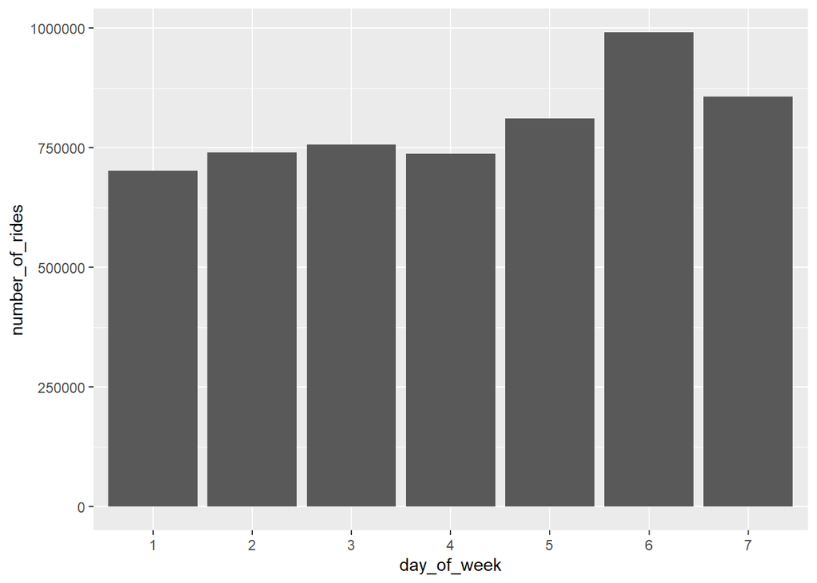

```r
all_data_trips_v1 %>%
  group_by(day_of_week) %>%
  summarise(number_of_rides = n()) %>%
  ggplot(mapping = aes(x = day_of_week, y = number_of_rides)) + geom_col()
```

The plot shows that most rides were started on Saturday(991047 rides), Sunday(857285 rides) followed by Friday(810508 rides). So most bikes are rented on the weekend.

Next, a plot of the ride_length or average_duration in minutes for every day of the week for members and casual riders is shown.

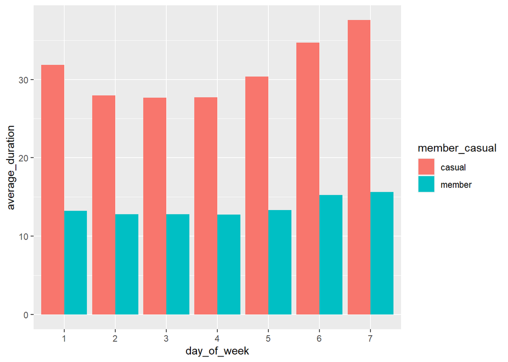

```r
all_data_trips_v1 %>%
  group_by(member_casual, day_of_week) %>%
  summarise(number_of_rides = n()
            ,average_duration = mean(ride_length_m)) %>%
  arrange(member_casual, day_of_week)  %>%
  ggplot(aes(x = day_of_week, y = average_duration, fill = member_casual)) +
  geom_col(position = "dodge")
```

The plot demonstrates that casual riders rent bikes for longer durations, especially on Sunday, Saturday, Friday (weekend) and on Monday. Members show a steady riding/using behavior, plus they also tend to ride a little longer on the weekend.

Here, number of rides per day for every rider type is plotted.

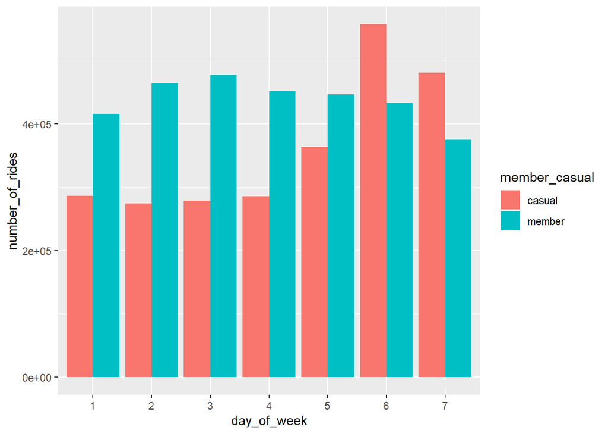

```r
all_data_trips_v1 %>%
  group_by(member_casual, day_of_week) %>%
  summarise(number_of_rides = n()
            ,average_duration = mean(ride_length_m)) %>%
  arrange(member_casual, day_of_week)  %>%
  ggplot(aes(x = day_of_week, y = number_of_rides, fill = member_casual)) +
  geom_col(position = "dodge")
```

#### Second Analysis Step: average ride length depending on rider type and number of each rider type

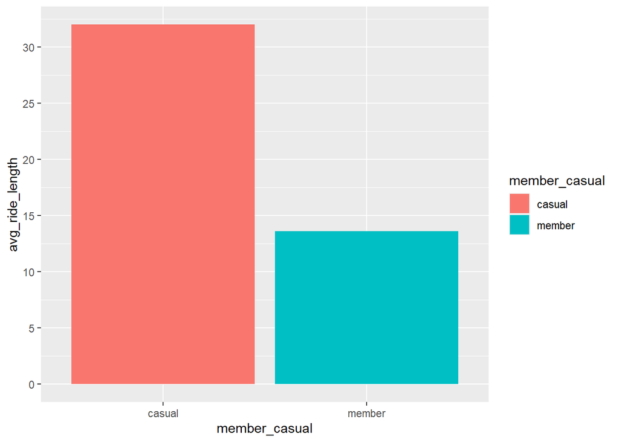

```r
all_data_trips_v1 %>%
  group_by(member_casual) %>%
  summarise(max(ride_length_m), min(ride_length_m),avg_ride_length = mean(ride_length_m)) %>%
  ggplot(aes(x = member_casual, y = avg_ride_length,fill=member_casual)) +
  geom_col()+ scale_y_continuous(breaks = seq(0, 40, by = 5))
```

So, the result shows that casual riders tend to rent bikes for longer mean durations than members (32 min to 13.6 min), in accordance with plot 2. Probably Members bike to work. Casual riders bike lesser in the weekdays as they may not use the bike to commute. However, in the weekend, casual riders use bikes probably for events like bike-race or for fitness.

Here, the overall rider count based on rider type is plotted

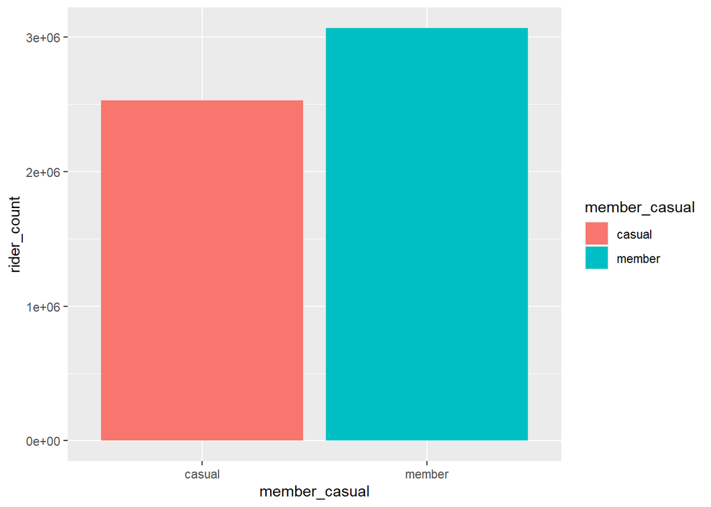

```r
all_data_trips_v1 %>%
  group_by(member_casual) %>%
  summarise(rider_count = n()) %>%
  ggplot(aes(x = member_casual, y = rider_count,fill=member_casual )) +
  geom_col()
```

The plot indicates that more than half of all riders are member riders (3/(3+2.5)=0,55)

#### Third Analysis Step: Exploring effect of seasonality

Here, the Function “season” of the library “metR” was used to assign season to months:

DJF (dec, Jan, Feb):winter

MAM(Mar, Appr, May):Spring

JJA(June, July, Aug):Summer

SON(Sept, Oct, Nov):Fall

```r
all_data_trips_v1$season <- season(all_data_trips_v1$month)
```

First, let us consider number of rides and ride length by weekday on each season

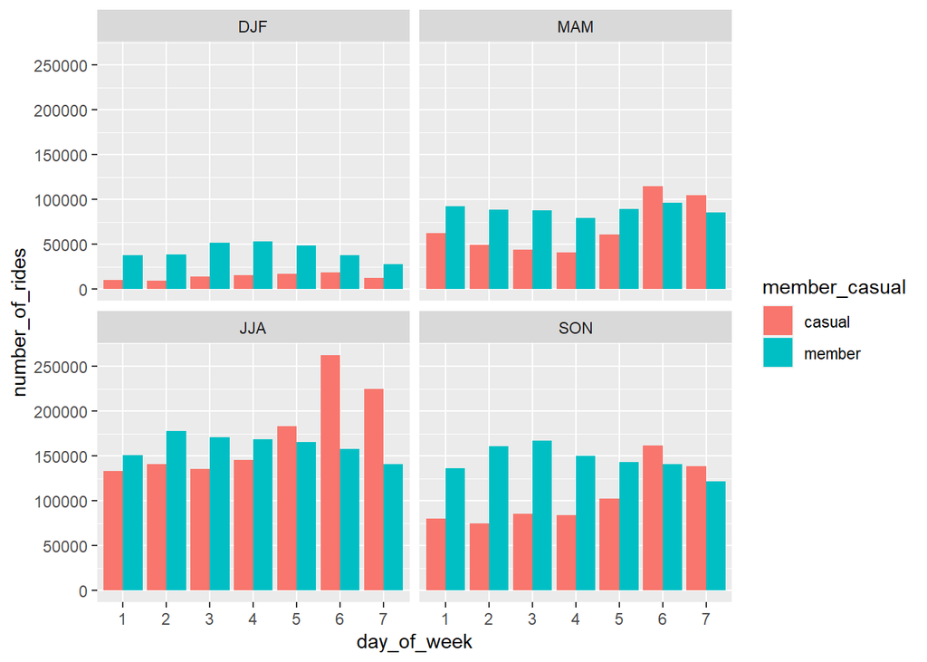

```r
all_data_trips_v1%>%
  group_by(season, day_of_week, member_casual) %>%
  summarise(number_of_rides = n()
  ,avg_ride_length = mean(ride_length_m)) %>%
ggplot() + geom_col(mapping = aes(x = day_of_week, y = number_of_rides, fill = member_casual), position = "dodge") + facet_wrap(~season) + scale_y_continuous(breaks = seq(0, 400000, by = 50000))
```

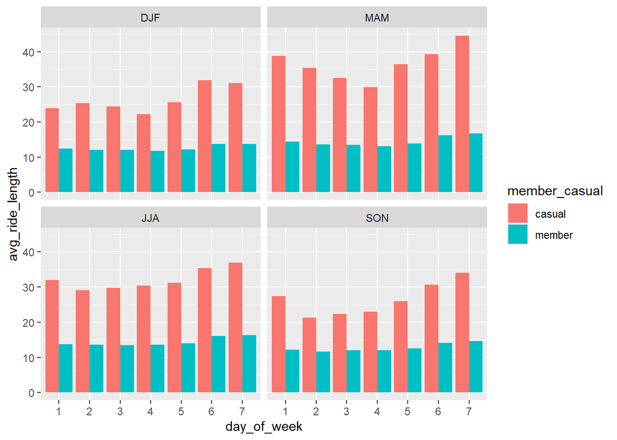

```r
all_data_trips_v1%>%
  group_by(season, day_of_week, member_casual) %>%
  summarise(number_of_rides = n()
  ,avg_ride_length = mean(ride_length_m)) %>%
ggplot() + geom_col(mapping = aes(x = day_of_week, y = avg_ride_length, fill = member_casual), position = "dodge") + facet_wrap(~season) + scale_y_continuous(breaks = seq(0, 50, by = 10))
```

Finally, generate a line plot for continuous change of number of rides along the whole year for the two rider types.

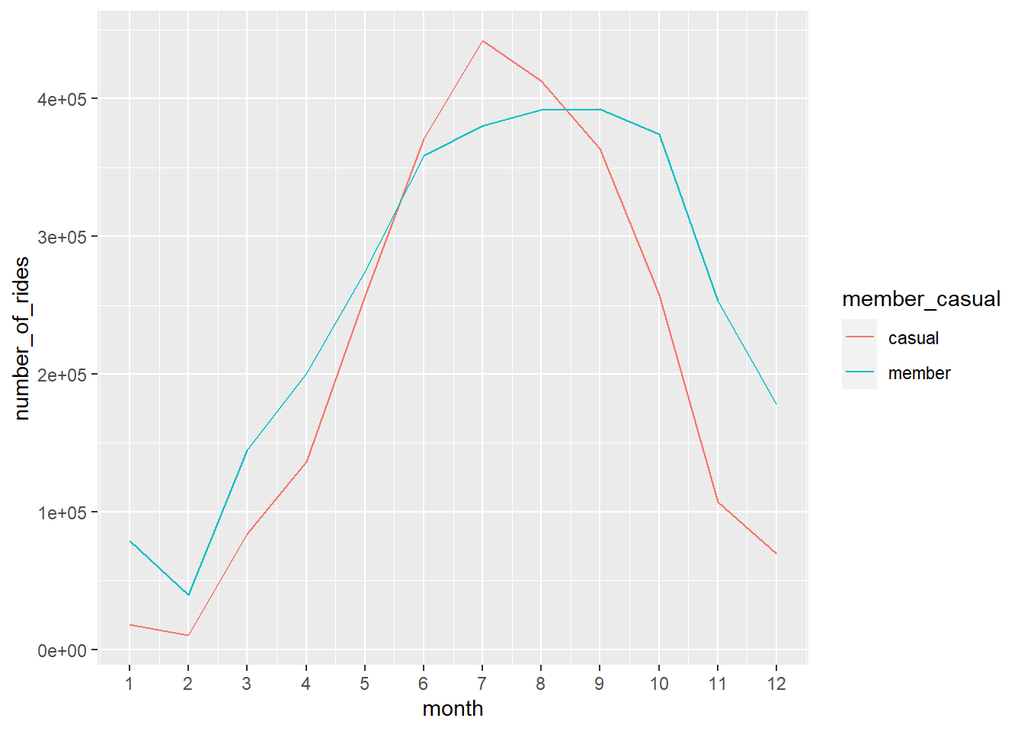

```r
all_data_trips_v1%>%
  group_by(month, member_casual) %>%
  summarise(number_of_rides = n()
  ,avg_ride_length = mean(ride_length_m)) %>%
ggplot() + geom_line(mapping = aes(x = month, y = number_of_rides, color = member_casual)) + scale_x_continuous(breaks = seq(1, 12, by = 1))
```

The plot indicates, for casual riders/members, ridership peaked around July/August (Summer months being the turning point) and February is the lowest.

### The Share phase

#### Conclusions/Summary of insights

Here is my conclusion for how annual members and casual riders use Cyclistic bikes differently?

- Casual rides peak during weekends (plot3). There is a high probability they are tourists visiting and sightseeing the city, or that they are ordinary Chicago residents who are riding bike in their leisure time during the weekend. The longer average ride time for casual rider (plot2), also peaking at the weekend, provides evidence for this point.
- Ride length for members are relatively shorter compared to casual riders. This could clarified as such, that most members use the bikes to commute on workdays. This clarification would also explain the short riding durations of members. They ride from point A to B, namely roughly always the same ride lengths and the same distance
- Ridership start to pick up (plot8) from February (from Spring through Summer)and start to decrease in August (from Fall through winter). This correlation is due to the seasonal changes. As the weather start to get warmer and more pleasant in February (start of Spring), more people starts to cycle, and inversely when the weather becomes less warm cold around September (start of Fall).
- More than 50% of the riders are annual members (plot5), suggesting that the company have already achieved a certain level of loyalty among its bike users. This indicates a positive message, namely that the company is going to be able to convince many casual riders to convert to members, and to keep the new members satisfied.

#### Recommendations

Give discounts for longer rides when you have a membership Longer rides can get some type of rewards program when they become members

- Appealing plans to casual riders should be introduced for the summer months, as the number of trips made by casual riders are high at this time of the year. Preparation for this marketing should be done in winter.
- As casual rider usage reach its highest point on the weekend, the marketing campaign can include weekend-only membership at a reasonable price. This could attract casual riders to convert to members.
- Probably reduce the long-term membership rate and and offer a discounted promotional rate. Increase the single-use weekend ride charges so casual riders will choose to go for membership option.